# Introduction to MetaboAnalystR

Basic Statistical Analysis (1Factor)

Author

Alex Sanchez-Pla

Published

June 1, 2024

# 1 Introduction to MetaboAnalyst

MetaboAnalystR comes with multiple vignetted (“tutorials”) to illustrate how to perform distinct actions and processes.

The document [MetaboAnalystR Package](https://www.metaboanalyst.ca/docs/RTutorial.xhtml) provides an *overview* to the distinct vignettes and links to each of them.

The corrent document is a short introduction to some statistical analyses that can be done to derive”differential” metabolites, that is those that show (significantly) distinct concebntrations between conditions.

This has been extracted from the tutorial [2.3. Statistical Analysis (one-factor)](https://www.metaboanalyst.ca/resources/vignettes/Statistical_Analysis_Module.html) which shows how to do it with higher detail.

## 1.1 Data for the analyses

We use the Cachexia dataset that has benn previously preprocessed in the document “1. Introduction to MetaboAnalystR”. The normalized `mSet`object has been saved to a binary file which is recovered here for further use.

```r
rm(list=ls())
library(MetaboAnalystR)
load(file="preprocessed_Cachexia.Rda")
# show(mSet)
```

# 2 Data Analysis

In this document we will mainly focus on the analyses that yield a list of differential compounds that can be later used for Enrichment Analyses.

However, in order to proceed “reasonably” we start with a multivariate exploration in order to detect if *there seem* to be differrences between the groups.

## 2.1 PCA visualization

```r
# Perform PCA analysis
mSet<-PCA.Anal(mSet)

# Create a 2D PCA score plot
mSet<-PlotPCA2DScore(mSet, "pca_score2d_0_", format = "png", dpi=72, width=NA, pcx= 1, pcy=2, reg=0, show=1, grey.scale=0)
```

All these plots go to files that can be included or explored apart.

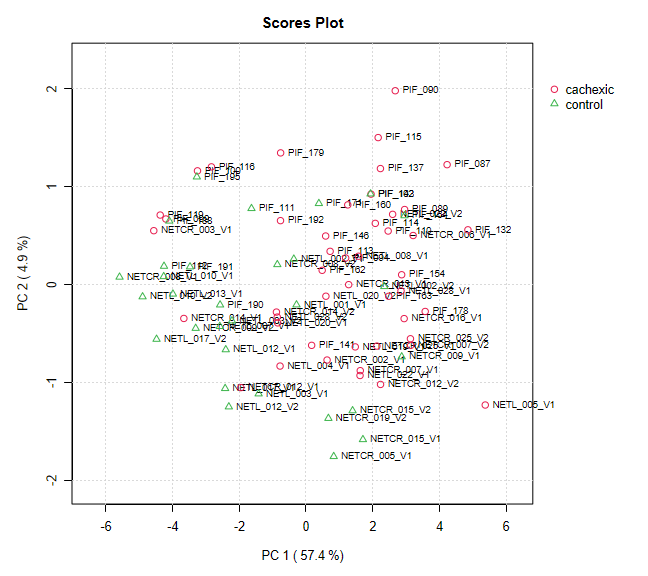

## 2.2 Fold change Analysis

The goal of fold-change (FC) analysis is to compare the absolute value of change between two group means. Since column-wise normalization (i.e. log transformation, mean-centering) will significantly alter absolute values, FC is calculated as the ratio between two group means using the data before column-wise normalization was applied.

```r
# Perform fold-change analysis on uploaded data, unpaired
mSet<-FC.Anal(mSet, 2.0, 0, FALSE)

# Plot fold-change analysis
mSet<-PlotFC(mSet, "fc_0_", "png", 72, width=NA)

# To view fold-change
mSet$analSet$fc$fc.log
```

```
1,6-Anhydro-beta-D-glucose       1-Methylnicotinamide
                  0.888690                  -0.052019
           2-Aminobutyrate       2-Hydroxyisobutyrate
                  1.312700                   0.633520
            2-Oxoglutarate         3-Aminoisobutyrate
                  1.098400                   1.329100
         3-Hydroxybutyrate       3-Hydroxyisovalerate
                  1.563700                   1.164900
          3-Indoxylsulfate     4-Hydroxyphenylacetate
                  0.857170                   0.263810
                   Acetate                    Acetone
                  1.266100                   0.664560
                   Adipate                    Alanine
                  1.952900                   1.141300
                Asparagine                    Betaine
                  0.852650                   1.004000
                 Carnitine                    Citrate
                  0.994090                   0.883620
                  Creatine                 Creatinine
                  1.763900                   0.932160
             Dimethylamine               Ethanolamine
                  1.120000                   0.729170
                   Formate                     Fucose
                  1.150600                   0.918770
                  Fumarate                    Glucose
                  1.262700                   2.553000
                 Glutamine                    Glycine
                  1.166100                   0.869890
                 Glycolate             Guanidoacetate
                  0.657790                   0.506100
                 Hippurate                  Histidine
                  1.075800                   1.013100
              Hypoxanthine                 Isoleucine
                  0.375470                   0.420550
                   Lactate                    Leucine
                  1.726900                   1.205400
                    Lysine                Methylamine
                  0.442780                   0.901220
           Methylguanidine        N,N-Dimethylglycine
                  0.517770                   1.342900
```

[output cut: 9 more lines]

```
                  0.720000                   1.032700
                 Threonine               Trigonelline
                  0.990220                   1.460400
    Trimethylamine N-oxide                 Tryptophan
                  1.077700                   0.967880
                  Tyrosine                     Uracil
                  0.953700                   0.207270
                    Valine                     Xylose
                  1.178900                   1.194000
             cis-Aconitate               myo-Inositol
                  1.589400                   1.537500
           trans-Aconitate         pi-Methylhistidine
                  0.811730                   0.771640
       tau-Methylhistidine
                  0.708800
```

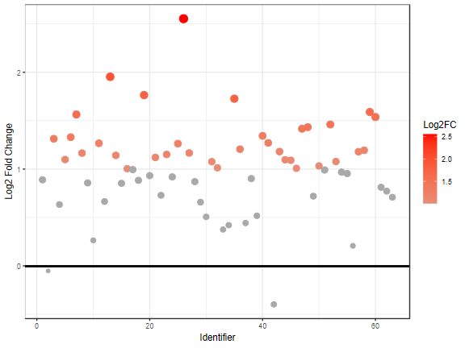

# 3 Significance (t-)tests

MetaboAnalystR supports various options for performing T-test analysis. Users can select the analysis type (paired), the group variance (equal.var), whether the test is parametric or non-parametric (nonpar), and the adjusted p-value (FDR) cut-off (threshp).

```r
# Perform T-test (parametric)
mSet<-Ttests.Anal(mSet, nonpar=F, threshp=0.05, paired=FALSE, equal.var=TRUE, pvalType = "fdr", all_results=TRUE)
```

```
[1] "Performing regular t-tests ...."
[1] "A total of 53 significant features were found."
```

The results of the t-test can be viewed plotting the p-values by indexed or with respct to the fold change.

```r
mSet<-PlotTT(mSet, imgName = "tt_0_", format = "png", dpi = 72, width=NA)
```

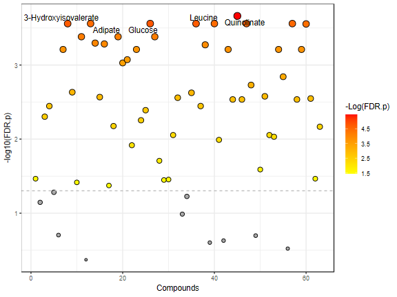

```r
mSet<-Volcano.Anal(mSet, FALSE, 2.0, 0, F, 0.1, TRUE, "raw")
```

```
[1] "A total of 57 significant features were found."
```

```r
mSet<-PlotVolcano(mSet, "volcano_0_", 1, 0, format ="png", dpi=72, width=NA)
```

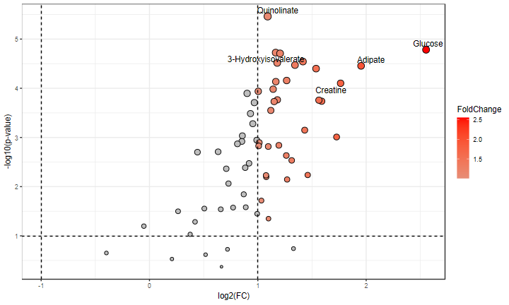

## 3.1 T-test results: Metabolites lists

The result of a comparison test is usually the base for enrichment analysis.

This result has been written in the `t_test_all.csv` or the `t_test.csv` files and can be recovered from there or from the `mSet`object.

In this case, where the number of features is small it can be shown as:

```r
sigMat <- mSet$analSet$tt$sig.mat
dim(sigMat)
```

```
[1] 57  4
```

```r
head(sigMat)
```

```
                     t.stat    p.value -log10(p)        FDR
Quinolinate          5.0149 3.4524e-06    5.4619 0.00021750
Glucose              4.6062 1.6443e-05    4.7840 0.00027576
3-Hydroxyisovalerate 4.5699 1.8835e-05    4.7250 0.00027576
Leucine              4.5598 1.9555e-05    4.7087 0.00027576
Succinate            4.4571 2.8608e-05    4.5435 0.00027576
Valine               4.4397 3.0502e-05    4.5157 0.00027576
```